# Varianciaelemzés és Kruskal-Wallis-próba összehasonlítása

A főállásból származó jövedelem vizsgálata foglalkozási csoportok szerint

# Bevezetés

A feladatban azt vizsgálom, hogy van-e különbség a főállásból származó havi nettó jövedelem között a különböző foglalkozási csoportokban.

A függő változó a `fojov`, amely a főállásból származó havi nettó jövedelmet tartalmazza ezer forintban. A csoportosító változó a `fogl4`, amely négy foglalkozási csoportot különböztet meg.

Először megnézem az egyutas varianciaelemzés (ANOVA) eredményét és annak feltételeit. Mivel a normalitás feltétele nem teljesül, az elemzést Kruskal-Wallis-próbával is elvégzem. A végén összehasonlítom a két eljárás eredményét.

# 1. Az adatok beolvasása és előkészítése

```r
# Szükséges csomagok
library(haven)

# Az SPSS adatfájl beolvasása
adat <- read_sav("fojov.sav", user_na = TRUE)

# Az SPSS-ben megadott hiányzó értékek NA értékké alakítása
adat <- zap_missing(adat)

# A jövedelem numerikus változó, a foglalkozási csoport pedig faktor legyen
adat$fojov <- as.numeric(zap_labels(adat$fojov))
adat$fogl4 <- as_factor(adat$fogl4)

# Csak a két vizsgált változót tartom meg, és elhagyom a hiányzó sorokat
elemzes <- data.frame(
  fojov = adat$fojov,
  csoport = adat$fogl4
)

elemzes <- na.omit(elemzes)
elemzes$csoport <- droplevels(elemzes$csoport)

# A felhasznált minta nagysága és a csoportok
dim(elemzes)
```

```
## [1] 1504    2
```

```r
table(elemzes$csoport)
```

```
##
## szakképzetlen fizikai   szakképzett fizikai     egyszerű szellemi
##                   458                   538                   293
##    vezető értelmiségi
##                   215
```

Az elemzésben 1504 megfigyelés maradt. A négy csoport a szakképzetlen fizikai, a szakképzett fizikai, az egyszerű szellemi és a vezető értelmiségi csoport.

# 2. Leíró statisztikák

Mielőtt elvégzem a próbákat, megnézem a csoportok átlagát, mediánját és szórását. Az ANOVA főleg a csoportátlagok közötti különbséget vizsgálja, a Kruskal-Wallis-próba pedig rangokon alapul, ezért a mediánokat is érdemes figyelembe venni.

```r
# Csoportonkénti leíró statisztikák
leiro <- data.frame(
  csoport = levels(elemzes$csoport),
  n = as.vector(table(elemzes$csoport)),
  atlag = as.vector(tapply(elemzes$fojov, elemzes$csoport, mean)),
  median = as.vector(tapply(elemzes$fojov, elemzes$csoport, median)),
  szoras = as.vector(tapply(elemzes$fojov, elemzes$csoport, sd))
)

leiro$atlag <- round(leiro$atlag, 2)
leiro$median <- round(leiro$median, 2)
leiro$szoras <- round(leiro$szoras, 2)

knitr::kable(leiro, col.names = c("Foglalkozási csoport", "N", "Átlag", "Medián", "Szórás"))
```

| Foglalkozási csoport | N | Átlag | Medián | Szórás |
| --- | --- | --- | --- | --- |
| szakképzetlen fizikai | 458 | 9.71 | 8 | 7.13 |
| szakképzett fizikai | 538 | 12.47 | 11 | 9.91 |
| egyszerű szellemi | 293 | 13.33 | 12 | 6.16 |
| vezető értelmiségi | 215 | 19.73 | 16 | 13.66 |

A jövedelem átlaga és mediánja minden következő foglalkozási csoportban magasabb. A mediánok rendre 8, 11, 12 és 16 ezer Ft. A vezető értelmiségi csoportban a legmagasabb mind az átlag, mind a medián.

A szórások is eléggé különböznek, és az átlagok több csoportban nagyobbak a mediánoknál. Ez arra utal, hogy a jövedelmek eloszlása nem szimmetrikus, illetve nagyobb kiugró értékek is előfordulnak.

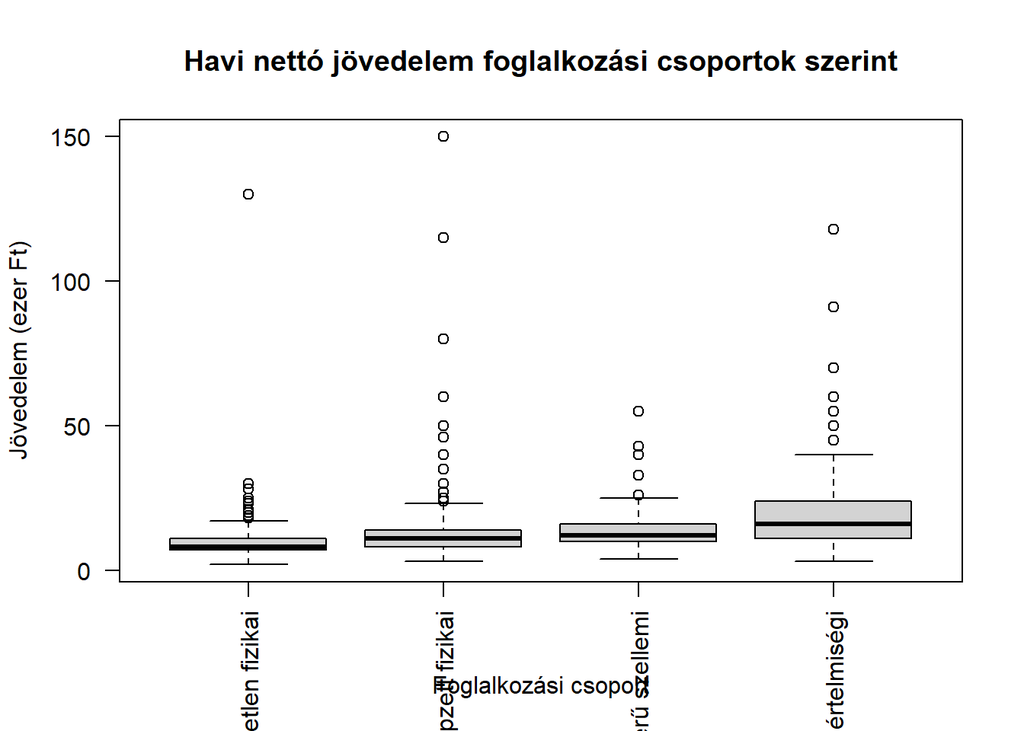

```r
# A csoportok eloszlásának szemléltetése
boxplot(
  fojov ~ csoport,
  data = elemzes,
  main = "Havi nettó jövedelem foglalkozási csoportok szerint",
  xlab = "Foglalkozási csoport",
  ylab = "Jövedelem (ezer Ft)",
  las = 2
)
```

A boxploton is látszanak a kiugró értékek, valamint az, hogy a négy csoport eloszlása és szóródása nem teljesen egyforma.

# 3. Az ANOVA feltételeinek ellenőrzése

Az egyutas ANOVA egyik fontos feltétele, hogy a modell maradékai közelítőleg normális eloszlásúak legyenek. Ezt Shapiro-Wilk-próbával és Q-Q ábrával ellenőrzöm.

## 3.1. Normalitás

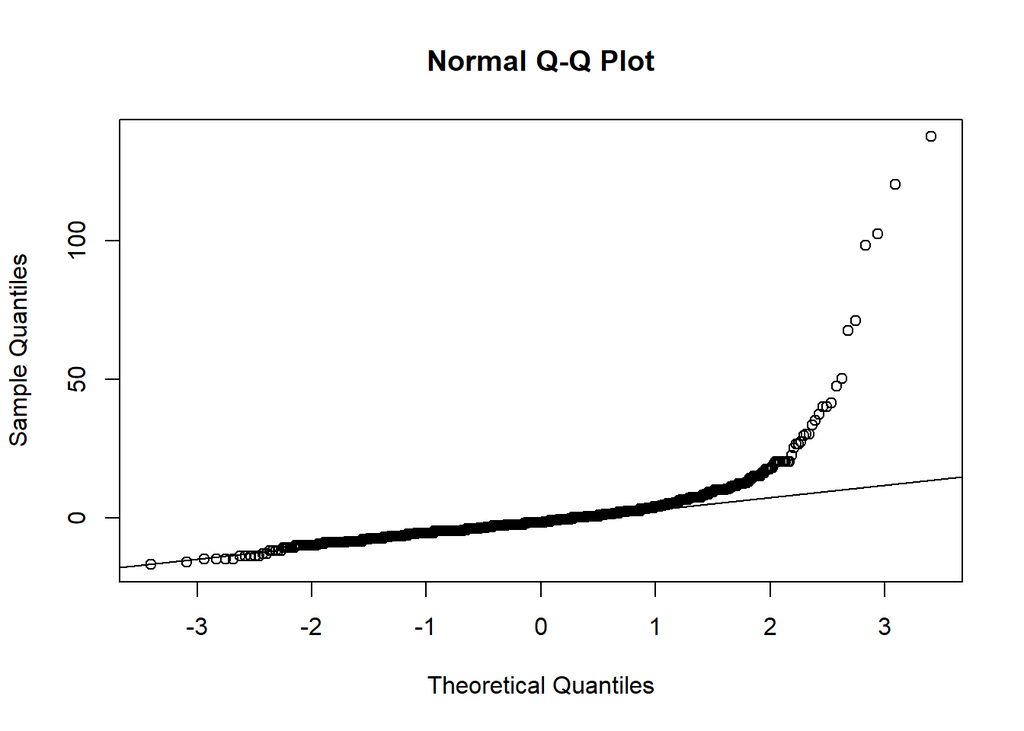

```r
# Egyutas ANOVA modell
anova_modell <- aov(fojov ~ csoport, data = elemzes)

# A modell maradékai
maradek <- residuals(anova_modell)

# Q-Q ábra
qqnorm(maradek)
qqline(maradek)
```

```r
# Shapiro-Wilk normalitásvizsgálat
shapiro.test(maradek)
```

```
##
##  Shapiro-Wilk normality test
##
## data:  maradek
## W = 0.58277, p-value < 2.2e-16
```

A Shapiro-Wilk-próba nullhipotézise az, hogy a vizsgált adatok normális eloszlásból származnak. Ha a p-érték 0,05-nél kisebb, akkor a normalitás feltételét elutasítjuk.

Az eredményben `W = 0,58`, a p-érték pedig 0,001-nél kisebb. Ez alapján a maradékok eloszlása nem tekinthető normálisnak. A Q-Q ábrán is látható eltérés az egyenestől, főleg a szélső értékeknél.

# 4. Egyutas varianciaelemzés

Az ANOVA nullhipotézise szerint a négy foglalkozási csoport átlagos jövedelme megegyezik. Az alternatív hipotézis szerint legalább egy csoport átlaga eltér a többitől.

```r
summary(anova_modell)
```

```
##               Df Sum Sq Mean Sq F value Pr(>F)
## csoport        3  14833    4944   58.41 <2e-16 ***
## Residuals   1500 126971      85
## ---
## Signif. codes:  0 '***' 0.001 '**' 0.01 '*' 0.05 '.' 0.1 ' ' 1
```

Az ANOVA eredménye `F(3, 1500) = 58,41`, `p < 0,001`. Ez szignifikáns eredmény, ezért a nullhipotézist elutasítom. Az ANOVA alapján van különbség a négy foglalkozási csoport átlagos jövedelme között.

Viszont az előző részben látható volt, hogy a normalitás feltétele nem teljesül, ezért ezt az eredményt érdemes a Kruskal-Wallis-próbával is ellenőrizni.

# 5. Kruskal-Wallis-próba

A Kruskal-Wallis-próba független csoportok összehasonlítására használható nemparaméteres eljárás. A próba nem igényli a függő változó normális eloszlását. Nem közvetlenül az átlagokkal, hanem az adatok rangjaival számol.

A nullhipotézis szerint a csoportok rangeloszlása megegyezik. Ha a p-érték kisebb 0,05-nél, akkor legalább egy csoport eltér a többitől.

```r
kruskal.test(fojov ~ csoport, data = elemzes)
```

```
##
##  Kruskal-Wallis rank sum test
##
## data:  fojov by csoport
## Kruskal-Wallis chi-squared = 260.3, df = 3, p-value < 2.2e-16
```

A Kruskal-Wallis-próba eredménye `H(3) = 260,30`, `p < 0,001`. Ez alapján a nullhipotézist elutasítom. A foglalkozási csoportok jövedelmi eloszlása között szignifikáns különbség van.

Ez az eredmény ugyanabba az irányba mutat, mint az ANOVA eredménye: a foglalkozási csoportok között valóban van jövedelmi különbség.

# 7. Az ANOVA és a Kruskal-Wallis-próba összehasonlítása

A két fő próba eredménye összességében megegyezik:

| Próba | Próbaérték | p-érték | Következtetés |
| --- | --- | --- | --- |
| Egyutas ANOVA | F(3, 1500) = 58,41 | < 0,001 | A csoportátlagok között van különbség. |
| Kruskal-Wallis | H(3) = 260,30 | < 0,001 | A csoportok rangeloszlása között van különbség. |

Mindkét eljárás szignifikáns különbséget mutat a foglalkozási csoportok között. Mivel a normalitás feltétele nem teljesült, ebben az esetben a Kruskal-Wallis-próba megfelelőbb választás a csoportok összehasonlítására.